# FLAMe case study

Luke Loken

April 03, 2018

## What do I do?

- Characterize within lake patterns of water chemistry
- Interpolate to generate spatially weighted distributions of water chemistry
- Automate these steps across multiple lakes and through time

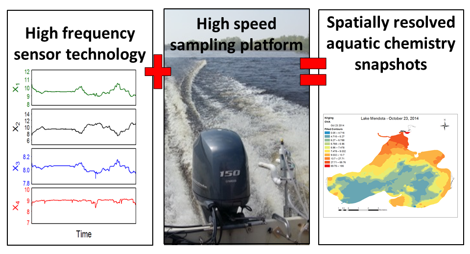

Crawford, Loken et al. 2015

## Code reflects my progression performing spatial analyses in R

- Old code was long scripts, loops, copy/paste
- New code using functions/apply statements, but I have yet to go back and tidy old code.

## Data example

- Methane measurements while boating around Little Satin Germain Lake.
- ~10,000 point observations distributed in grid like transects
- We can interpolate across the lake surface and estimate CH4 flux to the atmosphere for the entire lake?
- We also ask questions about the drivers and consequences of spatial heterogeneity within lakes

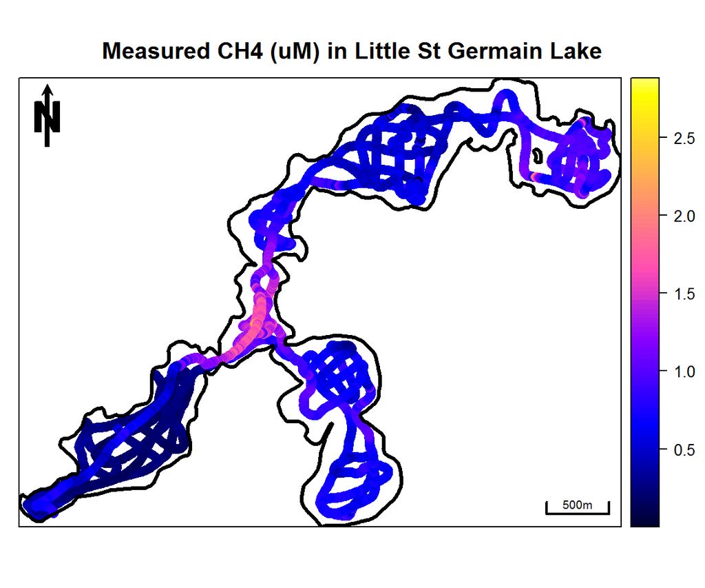

```
## [inverse distance weighted interpolation]
```

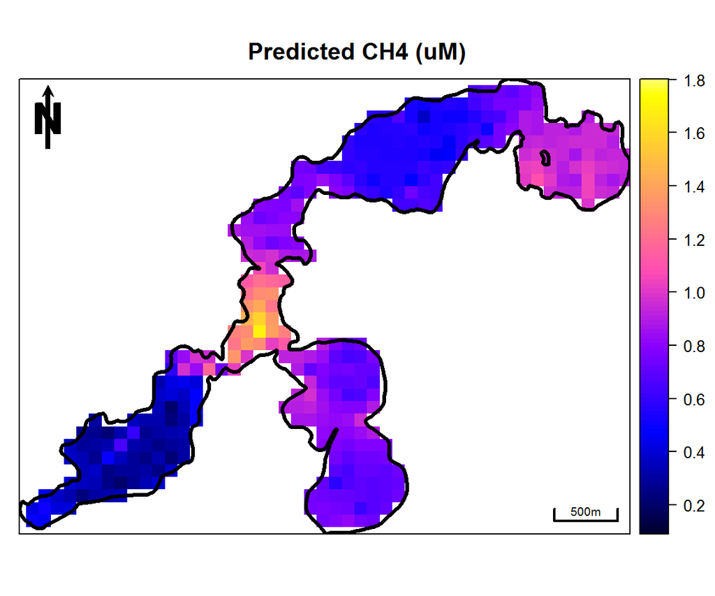

Convert Concentration to flux using a model of gas transfer velocity

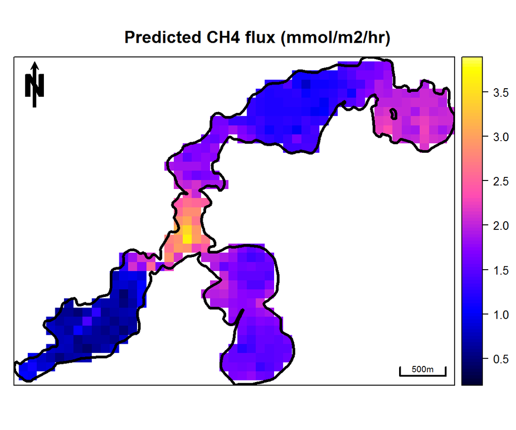

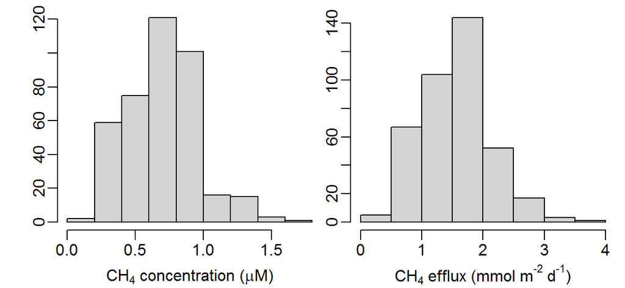

Clearly spatial patterns exist for methane concentration/flux. Estimates from a single location do not represent the entire lake surface.

## General questions to my research

- How variable are individual lakes?
- How does variability vary among variables? (Temperature vs dissolved oxygen)
- How does variability vary among lakes? (Big lakes vs small lakes)
- What are the dominant scales of variation? (small patches vs large patches)

## Example 2 - Within lake spatial variability among lakes

- Sampled 40 lakes in Northern Wisconsin across lake productivity, size, and morphometry gradients

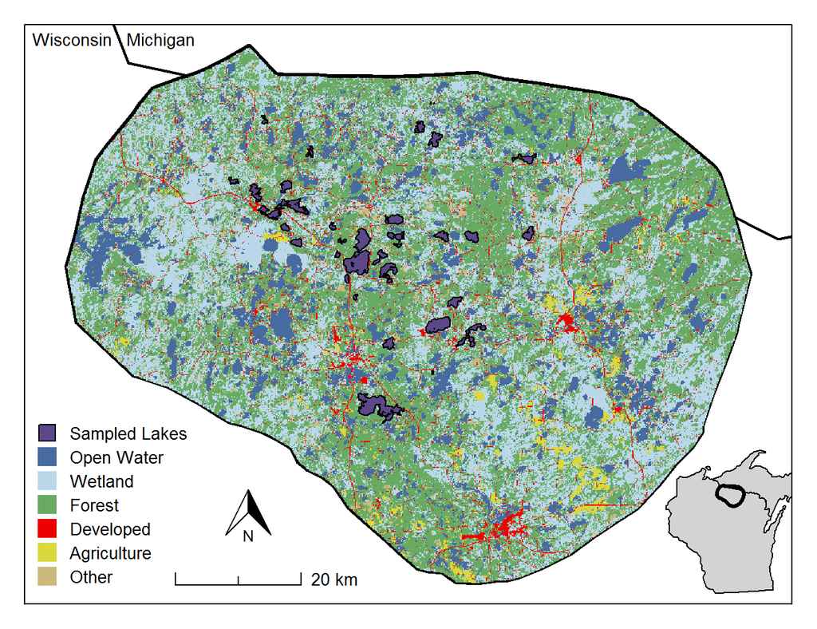

Northern Highland Lake District

- For each lake, statistics describing spatial heterogeneity were calculated for all measurements (Temperature, dissolved oxygen, etc.)
  - standard deviation
  - quartile dispersion
  - coefficient of variation
  - skewness
- We also evaluated spatial structure using semivariance and correlogram models
  - semivariance range
  - correlation at distance intervals

Semivariance models for 3 variables

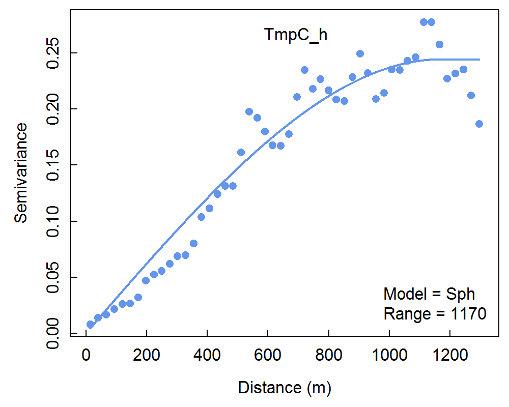

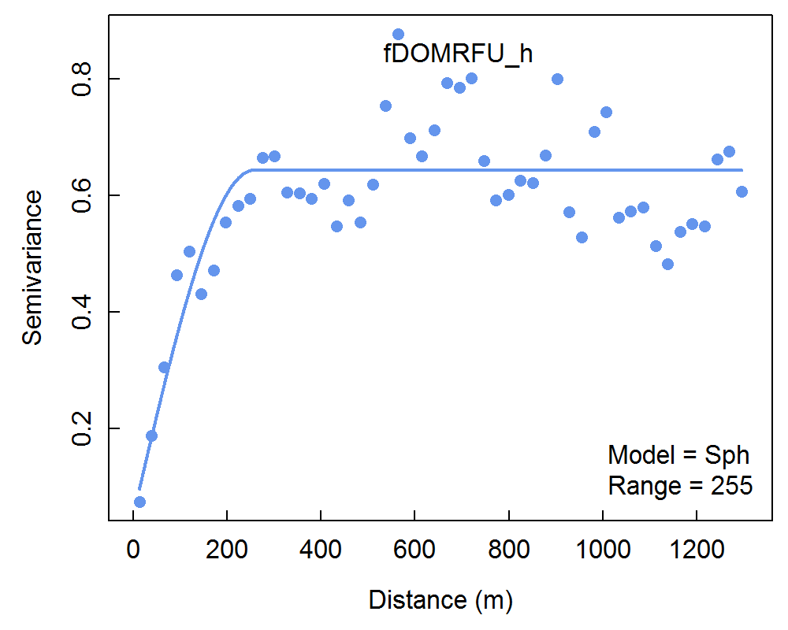

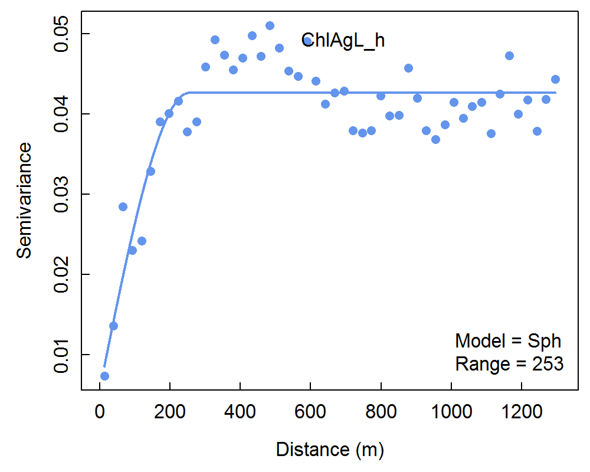

Semivariance range is the distance at which observations are no longer spatially autocorrelated.

In this example, temperature (left panel) has a greater semivariance range (~1000 m), while fDOM (middle) and chlorophyll (right) have shorter ranges (~250 m). In this example, we can say that the dominant scale of variation for temperature occurs at a broader scale than the other variables.

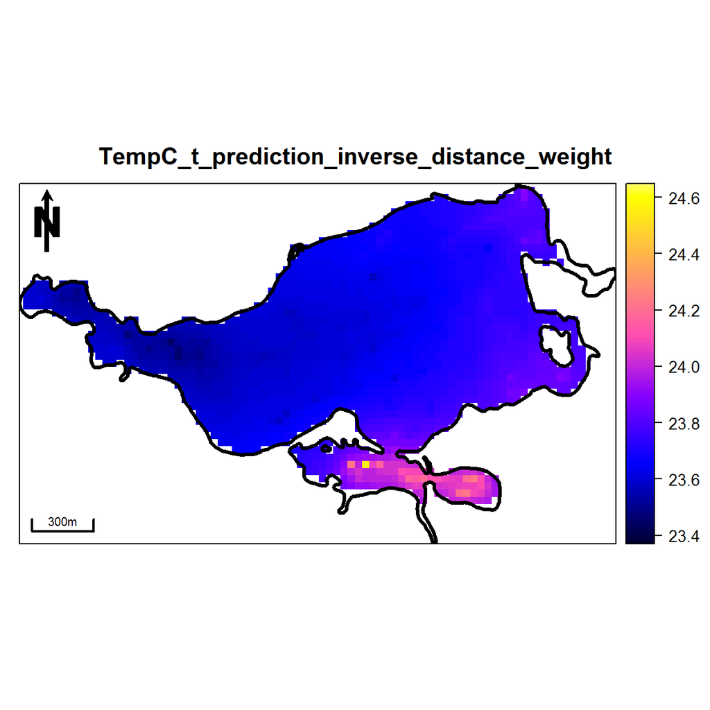

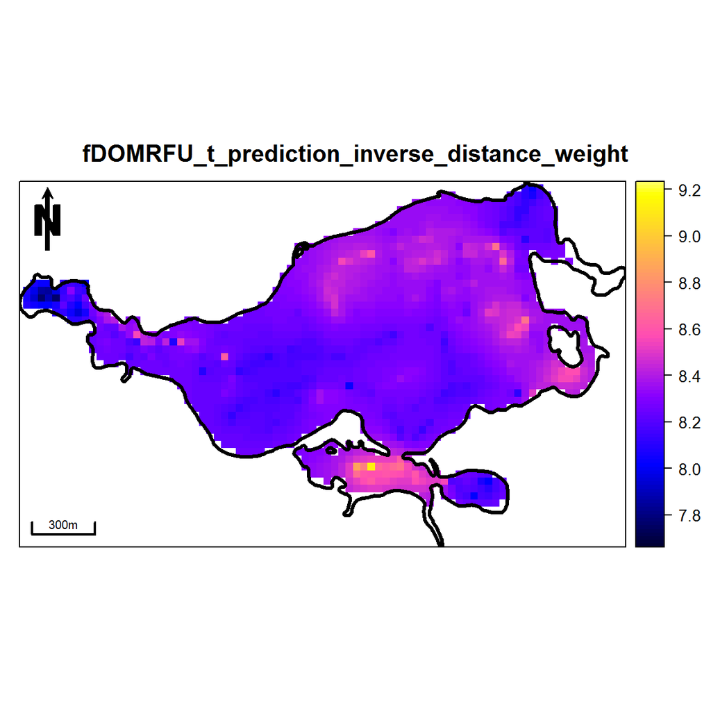

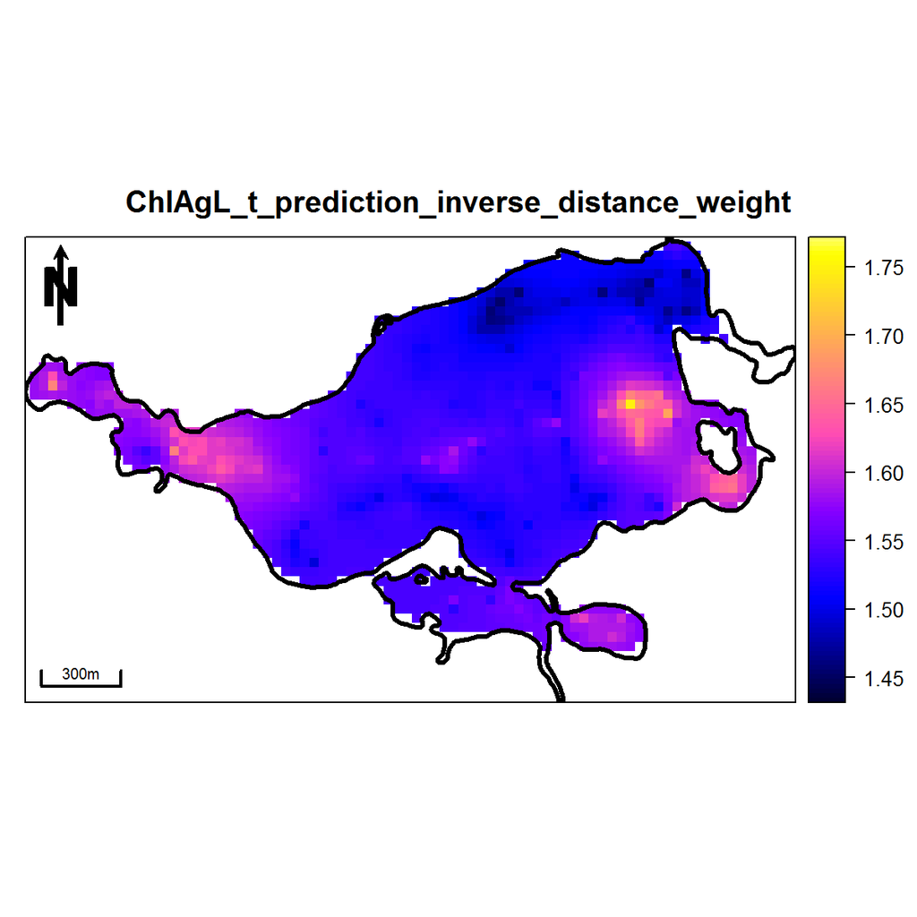

Looking at the maps, we see finer patches for fDOM and chlorophyll than temperature

## Semivariance modelling in R

- Uses the functions `variogram()`, `vgm()`, `fit.variogram()` in the `gstat` package

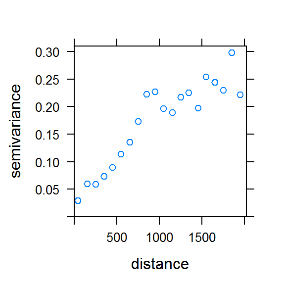

```r
library(gstat)

#Parameters for semivariogram calculation. Maximum distance (cutoff) and bin size (width)
cutoff=2000
width=100

# CH4 data are the 50th column in spatial points data frame 'LSG2'

# Calculate variogram
v = variogram(LSG2@data[,50]~1, LSG2, cutoff=cutoff, width=width)
plot(v)
```

- Now we need to fit a model
- What kind of model should we use?

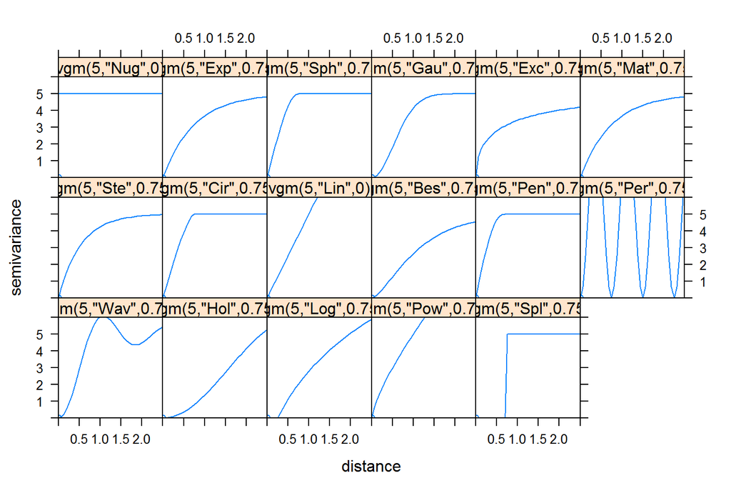

```r
#Look at a few types of semivariogram models
show.vgms(sill=5, range=0.75, ylim=c(0,6), xlim=c(0,2.5))
```

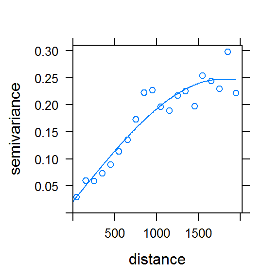

```r
models<-c('Nug', 'Lin', 'Sph', 'Gau')

# Guess sill, range, and nugget
# These help the fit.variogram function figure out the best model
est_sill<-median(v$gamma)
est_range<-cutoff/4
est_nugget<-v$gamma[1]

#fit model to variogram
#fit.method=2 weights closer observations more than distant ones.
v.fit <- fit.variogram(v, vgm(est_sill=est_sill, models, est_range=est_range, nugget=est_nugget), fit.method = 2)

# Look at model fit
plot(v, v.fit)
```

```r
v.fit
```

```
##   model      psill    range
## 1   Nug 0.02203928    0.000
## 2   Sph 0.22489710 1765.931
```

```r
#output semivariogram parameters
SemiRange <- v.fit$range[2]
SemiSill <- v.fit$psill[2]
```

Looks like a spherical model was selected, which does a pretty good of fitting data. `fit.variogram` uses a weighted sum of squared errors for fitting models You can adjust the weighting using the `fit.method` attribute in the `vgm` function

Or do this with a function and extract for multiple variables, days, and lakes

```r
# Function to fit variograms and extract range/model/sill
ExtractRangeSill <-function (SPdf, colname, models, plot, ...){

  #Subset data to remove NAs
  SPdf2<-SPdf[is.na(SPdf@data[,colname])==FALSE,]

  #Create variogram and estimate model parameters
  v <- variogram(SPdf2@data[,colname]~1, SPdf2, ...)
  est_sill<-median(v$gamma)
  est_range<-max(v$dist)/4
  est_nugget<-v$gamma[1]

  #Fit variogram model to variogram
  v.fit<-fit.variogram(v, vgm(est_sill=est_sill, models, est_range=est_range, nugget=est_nugget), ...)

  #output model type, sill, and range
  output<- data.frame(model=as.character(v.fit$model[nrow(v.fit)]), sill=v.fit$psill[nrow(v.fit)], range=v.fit$range[nrow(v.fit)])

  #Optional plotting
  if (missing(plot)){
  } else if (plot==T){
    print(plot(v, v.fit))
  } else {
  }

  return(output)

}

#Let's try it for one variable
head(LSG) #LSG is the spatialpointsdataframe
```

```
##                 ltime    Depth XCO2Dpp XCH4Dpp  TempC SPCuScm ChlARFU
## 1 2015-07-15 19:46:00 3.795174 92.4604 170.658 25.738    74.9    0.13
## 2 2015-07-15 19:46:01 3.866333 91.8642 170.928 25.732    75.0    0.13
## 3 2015-07-15 19:46:02 3.961216 91.7539 171.028 25.724    75.0    0.14
## 4 2015-07-15 19:46:03 3.913776 91.0657 171.618 25.715    75.0    0.14
## 5 2015-07-15 19:46:04 4.174694 91.3500 172.056 25.706    75.0    0.14
## 6 2015-07-15 19:46:05 3.961216 90.6574 172.076 25.695    75.0    0.15
##   ChlAugL BGAPCRFU BGAPCgL TurbFNU fDOMRFU fDOMQSU ODOsat ODOmgL   pH
## 1    0.32    -0.03    0.02    1.08    3.07    9.33  117.5   9.58 8.58
## 2    0.33    -0.02    0.03    1.08    3.07    9.33  117.5   9.58 8.58
## 3    0.36    -0.02    0.03    1.08    3.07    9.31  117.5   9.58 8.58
## 4    0.39    -0.02    0.02    1.05    3.06    9.31  117.6   9.58 8.59
## 5    0.40    -0.02    0.03    1.06    3.05    9.28  117.6   9.59 8.59
## 6    0.43    -0.02    0.03    1.05    3.05    9.26  117.6   9.59 8.59
##   Pressps XCO2Dppm_h XCO2Dppm_t XCH4Dppm_h XCH4Dppm_t TmpC_hy TempC_t
```

[output cut: 41 more lines]

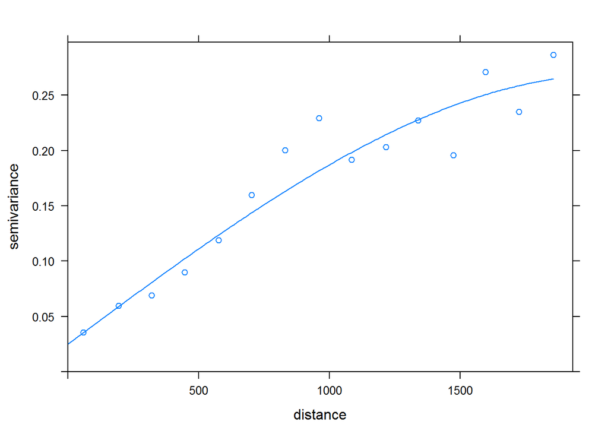

```r
models<-c("Nug", "Lin", "Sph") #Which models to try?

table<-ExtractRangeSill(LSG, colname='CH4uM_t', models=models, plot=T)
```

```r
print(table)
```

```
##   model     sill    range
## 1   Sph 0.243827 2081.026
```

Now let’s apply it to multiple columns (variables) in one dataset

```r
columns<-c('TempC_t', 'SPCScm_t', 'TrbFNU_t', 'ODOmgL_t', 'pH_tau', 'fDOMQSU_t', 'CH4uM_t', 'CO2uM_t', 'ChlARFU_t')

SemiVarList<-lapply(columns, function (x) ExtractRangeSill(SPdf=LSG, colname=x, models=models, plot=F))
#Clean up output table
SemiVarTable<-ldply(SemiVarList, data.frame)
SemiVarTable$variable <- columns
SemiVarTable<-SemiVarTable[c('variable', 'model', 'sill', 'range')]
print(SemiVarTable)
```

```
##    variable model        sill     range
## 1   TempC_t   Lin  0.12240851  270.1061
## 2  SPCScm_t   Lin  3.92059807 2010.2453
## 3  TrbFNU_t   Lin  4.97359471 2244.8226
## 4  ODOmgL_t   Sph  0.15410605 2182.3036
## 5    pH_tau   Lin  0.14298146 2295.9883
## 6 fDOMQSU_t   Lin 36.19913486 1778.8389
## 7   CH4uM_t   Sph  0.24382697 2081.0256
## 8   CO2uM_t   Lin  2.74468262 2127.3073
## 9 ChlARFU_t   Lin  0.06144535 2214.1438
```

# Why is this useful?

Looking across lakes in northern Wisconsin, we see that variables differ in their spatial structure within lakes.

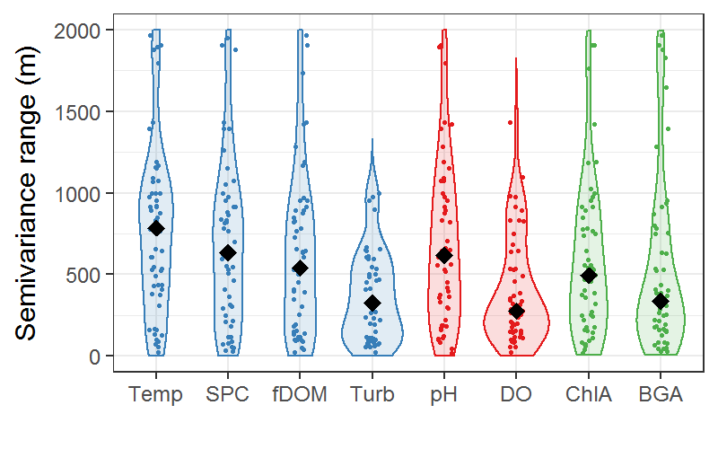

Semivariance ranges across lakes and variable types

- Temperature tends to have the greatest semivariance ranges. Dissolved oxygen, chlorophyll, blue green algae, and turbidity have shorter ranges.
- Thus spatial structure occurs at finer scales for biotic varibles than physics!

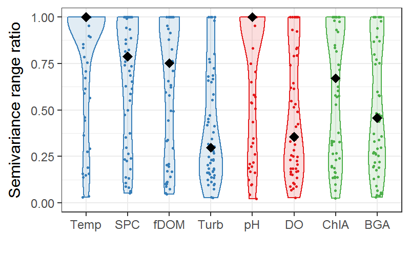

Semivariance range ratios across lakes and variable types

- The same data as above, but ranges divided by lake size. A range ratio of 1 means the semivariance occured at the lake scale. Smaller ratios means the scale of variation occured at finer spatial scales
- In more than 50% of the lakes, the dominant scale of variation for temperature occurred at the lake scale (ratio=1).

# Drivers of within lake variation among lakes?

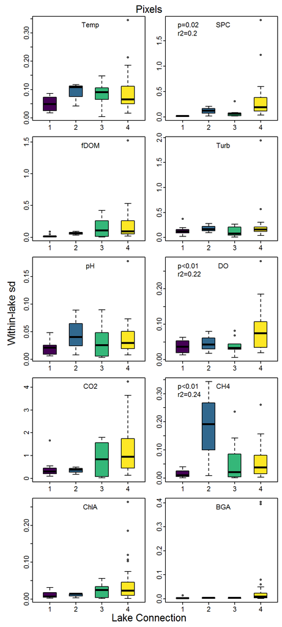

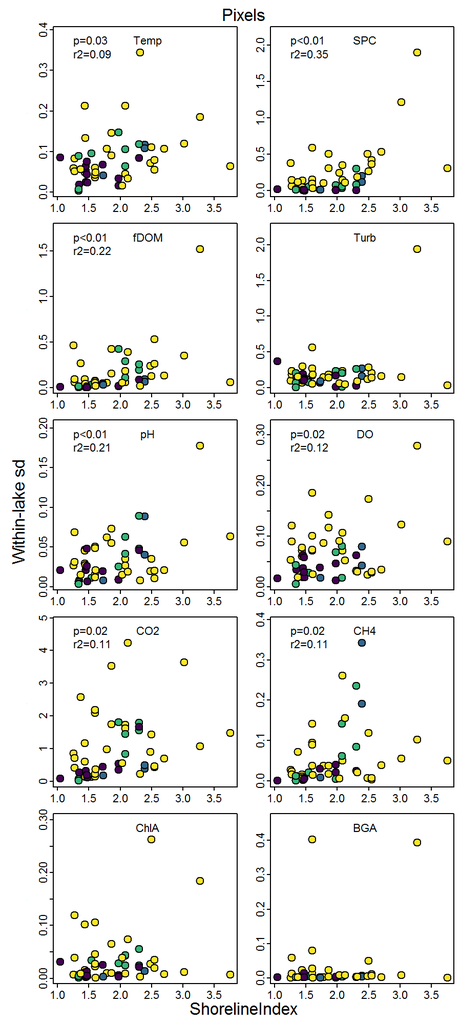

- Best GLM models often select landscape position (or variables related to landscape position) and shoreline development index as lake scale predictors of within lake variability.
- Lakes lower in the landscape and lakes with more comlicated shorelines have greater within lake variation

# Take home points

- R is becoming more popular for spatial analysis, but it can be frustrating.
- Most modelling and interpolation methods require more inputs than may seem unnecessary. However, interpolation models probably should not be fit without considering the problem. I see in arcmap models you can click your way to success with defaults, but in reality you should consider all the assumptions with those choices.

El Fin